# Assignment2_setA

Assignment No :2 set A

Q1) Write a Python program to find the maximum and minimum value of a given flattened array. Expected Output: Original flattened array: [[0 1] [2 3]] Maximum value of the above flattened array: 3 Minimum value of the above flattened array: 0

```python
import numpy as np
import sympy
import pandas as pd
import itertools
import matplotlib.pyplot as plt
import seaborn as sns
```

```python
arr = np.array([[0,1],[2,3]])
print("original flatterned array :")
print(arr)

arr1=np.array([0,1])
arr2=np.array([2,3])

arr3=[arr1]+[arr2]

max_value=np.max(arr3)
min_value=np.min(arr3)
```

```
original flatterned array :
[[0 1]
 [2 3]]
```

```python
print("Max Value :",max_value)
```

```
Max Value : 3
```

```python
print("Min Value :",min_value)
```

```
Min Value : 0
```

Q2) Write a python program to compute Euclidian Distance between two data points in a dataset. [Hint: Use linalgo.norm function from NumPy]

```python
point1 = np.array((1, 2, 3))
point2 = np.array((1, 1, 1))

dist = np.linalg.norm(point1 - point2) # calculating Euclidean distance using linalg.norm()

print(dist)
```

```
2.23606797749979
```

Q3) Create one dataframe of data values. Find out mean, range and IQR for this data.

```python
data = pd.DataFrame({"values" : [2, 4, 56, 5, 2, 8, 56, 23, 78, 5]})

mean_value = np.mean(data['values'])
range_value = np.max(data['values']) - np.min(data['values'])
q1 = np.percentile(data['values'], 25)
q2 = np.percentile(data['values'], 75)

iqr = q2 - q1

print("Data Values ")
print(data)

print("\nMean Value is ",mean_value)
print("Range Value ",range_value)

print("IQR : ",iqr)
```

```
Data Values
   values
0       2
1       4
2      56
3       5
4       2
5       8
6      56
7      23
8      78
9       5

Mean Value is  23.9
Range Value  76
IQR :  43.5
```

Q4) Write a python program to compute sum of Manhattan distance between all pairs of points.

```python
def manhattan_distance(p1, p2):
    return abs(p2[0] - p1[0]) + abs(p2[1] - p1[1])

def sum_manhattan_distances(points):
    n = len(points)
    total_distance = 0

    # Iterate over all pairs of points using nested loops
    for i in range(n):
        for j in range(i + 1, n):
            total_distance += manhattan_distance(points[i], points[j])

    return total_distance

points = [(1, 6), (4, 5), (9, 4)]
total_manhattan_distance = sum_manhattan_distances(points)
print("Sum of Manhattan distances between all pairs of points:", total_manhattan_distance)
```

```
Sum of Manhattan distances between all pairs of points: 20
```

Q5) Write a NumPy program to compute the histogram of nums against the bins. Sample Output: nums: [0.5 0.7 1. 1.2 1.3 2.1] bins: [0 1 2 3] Result: (array([2, 3, 1], dtype=int64), array([0, 1, 2, 3]))

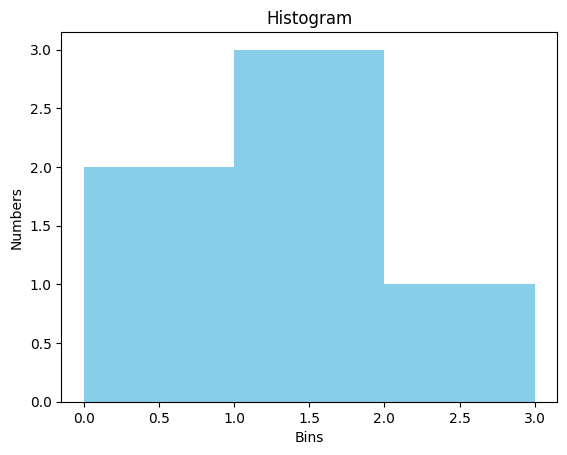

```python
nums = np.array([0.5, 0.7, 1.0, 1.2, 1.3, 2.1])
bi = [0, 1, 2, 3]
plt.hist(nums, bins = bi, color = 'skyblue')
plt.title("Histogram")
plt.xlabel("Bins")
plt.ylabel("Numbers")
plt.show()
```

Q6) Create a dataframe for students’ information such name, graduation percentage and age. Display average age of students, average of graduation percentage. And, also describe all basic statistics of data. (Hint: use describe()).

```python
data = pd.DataFrame({"Name" : ["Omkar", "Manish", "Sandhya", "Kiran", "Monya"],
                     "Percentage" : [45.6, 56.8, 90.9, 45.7, 34.0],
                     "Age" : [21, 20, 25, 21, 19]})
data
```

|  | Name | Percentage | Age |
| --- | --- | --- | --- |
| 0 | Omkar | 45.6 | 21 |
| 1 | Manish | 56.8 | 20 |
| 2 | Sandhya | 90.9 | 25 |
| 3 | Kiran | 45.7 | 21 |
| 4 | Monya | 34.0 | 19 |

```python
data["Age"].mean()
```

```
21.2
```

```python
data["Percentage"].mean()
```

```
54.6
```

```python
data.describe()
```

|  | Percentage | Age |
| --- | --- | --- |
| count | 5.000000 | 5.000000 |
| mean | 54.600000 | 21.200000 |
| std | 21.835178 | 2.280351 |
| min | 34.000000 | 19.000000 |
| 25% | 45.600000 | 20.000000 |
| 50% | 45.700000 | 21.000000 |
| 75% | 56.800000 | 21.000000 |
| max | 90.900000 | 25.000000 |